# Hierarchical Models

Martin Ingram

08/08/2019

# Hierarchical Models

In this part, we are going to learn about hierarchical models.

Hierarchical models are one of the major reasons people like Bayesian inference. A classical version of them is known as “mixed models” or “random effects models” and can be fit with tools like `lme4` in R, but Bayesian versions can give more flexibility and sometimes work better when there is not a lot of data.

The key idea in hierarchical models is that we introduce another level of hierarchy in the model. Let’s motivate why we might want to do this using the species distribution modelling example. Remember our model

$$\theta_1 \sim \mathcal{N}(0, 1^2) \\
\theta_2 \sim \mathcal{N}(0, 1^2) \\
y_i \sim \textrm{Bern}(\textrm{logit}^{-1}(\theta_1 x_i + \theta_2))$$

Now let’s imagine we want to model several species at the same time. How would we do that? Two ideas:

1. We could pretend there is no difference between the species – after all they’re all birds, so they’re probably similar in some ways. We just make our $x$ and $y$ vectors longer and have more data to fit $\theta_1$ and $\theta_2$.
2. Perhaps we think that each bird is unique and needs its own coefficients. In that case, we could just fit the same model to each species and look at them separately.

Neither of these seem that satisfying, and in fact, we can consider a third option:

3. The birds are different, but they also likely have *some* shared characteristics, which we might miss out on by modelling them all separately. We can fit a hierarchical model to explore that.

How do we do that? We introduce another level of hierarchy. We can do that in the following way. To keep it simple, we’ll first put a hierarchical prior on the slope $\theta_1$ only.

$$\mu_1 \sim \mathcal{N}(0, 1) \\
\sigma_1 \sim \mathcal{N^+}(0, 1) \\
\textrm{(The priors here could be different -- just an example)} \\
\theta_{11} ... \theta_{1J} \sim \mathcal{N}(\mu_1, \sigma_1^2) \\
\theta_{21} ... \theta_{2J} \sim \mathcal{N}(0, 1^2) \\
y_{ij} \sim \textrm{Bern}(\textrm{logit}^{-1}(\theta_{1j} x_i + \theta_{2j}))$$

Here, I’m using $\mathcal{N}^+$ to denote what’s called the half-normal distribution, which is a normal distribution truncated at zero (negative standard deviations don’t make sense).

Let’s see what’s going on here. First of all, let’s look at the bottom part. We now have $J$ different species, so we need $J$ different slopes and interecepts: those are the $\theta_{11} ... \theta_{1J}$ and $\theta_{21} ... \theta_{2J}$. For the same reason, we’ve also changed the last line to now be $y_{ij}$, because we now have a presence or absence for each of the $I$ sites and $J$ species, collected into the matrix $Y$.

So far, that’s just what we had to do to fit $J$ species at the same time. The hierarchical bit is the stuff at the top. Rather than giving each $\theta_{11}$ a $\mathcal{N}(0, 1)$ prior, we’re actually *also inferring what the mean and variance of these slopes is*. On the top two lines we’re providing what’s called a *hyperprior* because it is, in a sense, a prior on the prior for the slope.

This can be a bit confusing, and it took me a while to understand. But it’s very neat, because it does what we hoped it might. Let’s see how. If the birds’ reactions to $x$ are all similar, the hierarchical model may learn that $\sigma_1$ is small. In that case, we’re close to case (1) from earlier: all the species are quite similar, and we’re giving them very similar coefficients $\theta_{1j}$. On the other hand, perhaps the data suggest that $\sigma_1$ is large. This time, we’re close to case (2): fitting all species separately. The nice thing about hierarchical models is that they can strike a compromise and learn the variation between species, rather than forcing (1) or (2).

Let’s see what this looks like in Stan. First, let’s load our data again and prepare it:

```r
x <- read.csv('./x_train.csv', row.names=1)
y <- read.csv('./y_train.csv', row.names=1, check.names=FALSE)

x_scaled <- scale(x)
x_fit <- x_scaled[, 1]

set.seed(1)

# Pick some birds
birds_to_use <- sample(colnames(y), size=16, replace = FALSE)
print('Picked:' )
```

```
## [1] "Picked:"
```

```r
print(birds_to_use)
```

```
##  [1] "Sage Thrasher"           "Blue Jay"
##  [3] "Lesser Nighthawk"        "Grace's Warbler"
##  [5] "Blue-headed Vireo"       "Western Meadowlark"
##  [7] "Ovenbird"                "Cooper's Hawk"
##  [9] "Black-and-white Warbler" "Wood Thrush"
## [11] "Cactus Wren"             "Cedar Waxwing"
## [13] "Curve-billed Thrasher"   "Turkey Vulture"
## [15] "Grasshopper Sparrow"     "Green Heron"
```

```r
y <- y[, birds_to_use]
```

Now let’s write our Stan model:

```r
library(rstan)
rstan_options(auto_write = TRUE)
options(mc.cores=parallel::detectCores())
model <- stan_model('./varying_slopes.stan')
```

```
data {
  int n_obs; // Number of observations
  int n_species; // Number of species
  int y[n_obs, n_species]; // Presence / absence at each site
  vector[n_obs] x; // Covariate
}
parameters {
  real<lower=0> slope_sd;
  real slope_mean;
  vector[n_species] theta_1; // Slopes
  vector[n_species] theta_2; // Intercept
}
model {
  // Priors
  // Note we could be using something called the "non-centred parameterization" here,
  // but to keep it simple we won't.
  // If you want to learn what to do, check this out:
  // https://mc-stan.org/docs/2_18/stan-users-guide/reparameterization-section.html
  slope_sd ~ normal(0, 1);
  slope_mean ~ normal(0, 1);

  theta_1 ~ normal(slope_mean, slope_sd);
  theta_2 ~ normal(0, 1);

  // Loop over species for likelihood
  for (j in 1:n_species) {
    y[:, j] ~ bernoulli_logit(theta_1[j] * x + theta_2[j]);
  }

}
```

And we’ll give it the data it needs:

```r
stan_data <- list(
  n_obs = length(x_fit),
  n_species = ncol(y),
  y = y,
  x = x_fit
)
```

Now we can draw samples:

```r
model_results <- sampling(model, data=stan_data)
```

Notice that this model takes longer to fit (about a minute on my machine). We now have 16 species, each with over 1000 observations, so it’s maybe not that surprising. Stan claims to be faster than JAGS or BUGS, and greta promises to be even faster. But in my experience, you definitely often need patience when you’re using MCMC.

Let’s look at the usual fit statement:

```r
model_results
```

```
## Inference for Stan model: varying_slopes.
## 4 chains, each with iter=2000; warmup=1000; thin=1;
## post-warmup draws per chain=1000, total post-warmup draws=4000.
##
##                 mean se_mean   sd     2.5%      25%      50%      75%
## slope_sd        0.88    0.00 0.18     0.62     0.76     0.86     0.98
## slope_mean      0.19    0.00 0.22    -0.25     0.05     0.19     0.33
## theta_1[1]      1.33    0.00 0.12     1.10     1.25     1.33     1.42
## theta_1[2]     -0.65    0.00 0.06    -0.77    -0.69    -0.65    -0.61
## theta_1[3]      0.87    0.00 0.16     0.55     0.76     0.88     0.98
## theta_1[4]      1.24    0.00 0.19     0.88     1.11     1.24     1.37
## theta_1[5]     -0.64    0.00 0.08    -0.80    -0.70    -0.64    -0.59
## theta_1[6]      1.34    0.00 0.08     1.18     1.28     1.34     1.39
## theta_1[7]     -0.62    0.00 0.06    -0.74    -0.66    -0.62    -0.58
## theta_1[8]      0.04    0.00 0.09    -0.15    -0.03     0.04     0.10
## theta_1[9]     -0.58    0.00 0.07    -0.72    -0.62    -0.58    -0.53
## theta_1[10]    -0.37    0.00 0.06    -0.49    -0.41    -0.37    -0.33
## theta_1[11]     1.04    0.00 0.13     0.79     0.95     1.03     1.12
## theta_1[12]    -1.09    0.00 0.08    -1.24    -1.14    -1.09    -1.04
## theta_1[13]     1.04    0.00 0.13     0.79     0.95     1.04     1.13
## theta_1[14]     0.28    0.00 0.05     0.18     0.25     0.28     0.32
## theta_1[15]     0.25    0.00 0.06     0.13     0.21     0.25     0.29
## theta_1[16]    -0.21    0.00 0.07    -0.34    -0.25    -0.21    -0.17
## theta_2[1]     -3.71    0.00 0.18    -4.08    -3.83    -3.71    -3.58
## theta_2[2]      0.50    0.00 0.05     0.39     0.46     0.50     0.53
## theta_2[3]     -4.32    0.00 0.23    -4.79    -4.47    -4.31    -4.16
## theta_2[4]     -5.10    0.00 0.33    -5.78    -5.32    -5.09    -4.87
## theta_2[5]     -1.96    0.00 0.08    -2.12    -2.02    -1.96    -1.91
## theta_2[6]     -1.33    0.00 0.07    -1.47    -1.38    -1.33    -1.28
## theta_2[7]     -0.85    0.00 0.05    -0.96    -0.89    -0.85    -0.82
## theta_2[8]     -2.45    0.00 0.09    -2.64    -2.52    -2.45    -2.39
## theta_2[9]     -1.46    0.00 0.07    -1.59    -1.50    -1.46    -1.41
## theta_2[10]    -0.72    0.00 0.05    -0.82    -0.75    -0.72    -0.68
## theta_2[11]    -3.86    0.00 0.20    -4.27    -3.98    -3.85    -3.72
## theta_2[12]    -0.46    0.00 0.06    -0.58    -0.50    -0.46    -0.43
## theta_2[13]    -4.01    0.00 0.20    -4.42    -4.14    -4.00    -3.87
## theta_2[14]    -0.13    0.00 0.05    -0.23    -0.16    -0.13    -0.09
## theta_2[15]    -1.44    0.00 0.06    -1.56    -1.48    -1.44    -1.40
## theta_2[16]    -1.55    0.00 0.07    -1.69    -1.60    -1.55    -1.51
## lp__        -9959.51    0.11 4.12 -9968.35 -9962.15 -9959.18 -9956.54
```

[output cut: 26 more lines]

```
## theta_2[8]     -2.28  6899    1
## theta_2[9]     -1.32  6571    1
## theta_2[10]    -0.61  7287    1
## theta_2[11]    -3.50  4901    1
## theta_2[12]    -0.35  5952    1
## theta_2[13]    -3.62  5123    1
## theta_2[14]    -0.03  6863    1
## theta_2[15]    -1.32  5804    1
## theta_2[16]    -1.42  5995    1
## lp__        -9952.51  1495    1
##
## Samples were drawn using NUTS(diag_e) at Sun Aug 11 18:23:07 2019.
## For each parameter, n_eff is a crude measure of effective sample size,
## and Rhat is the potential scale reduction factor on split chains (at
## convergence, Rhat=1).
```

Notice first that everything looks good in terms of $\hat{R}$ and $n_{eff}$, so that’s good. Let’s take a look at what our hierarchical prior looks like:

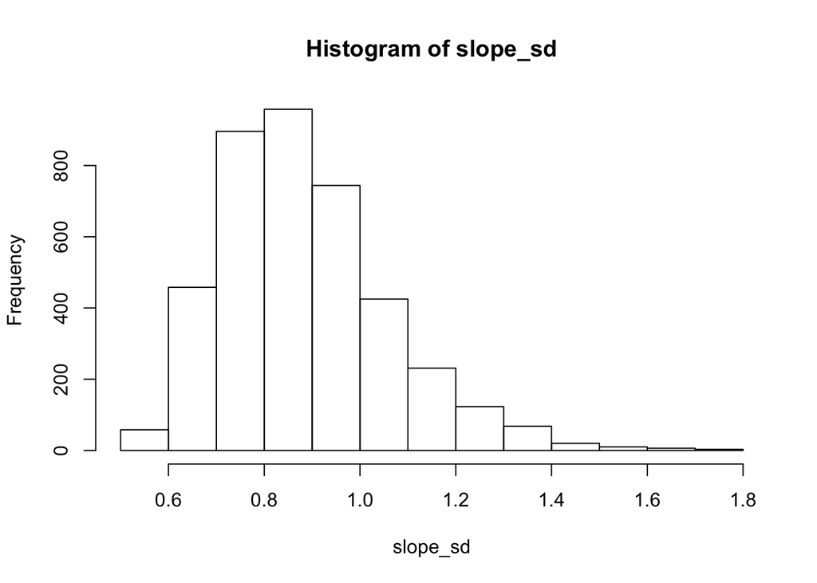

```r
slope_sd <- extract(model_results)$slope_sd
slope_mean <- extract(model_results)$slope_mean

hist(slope_sd)
```

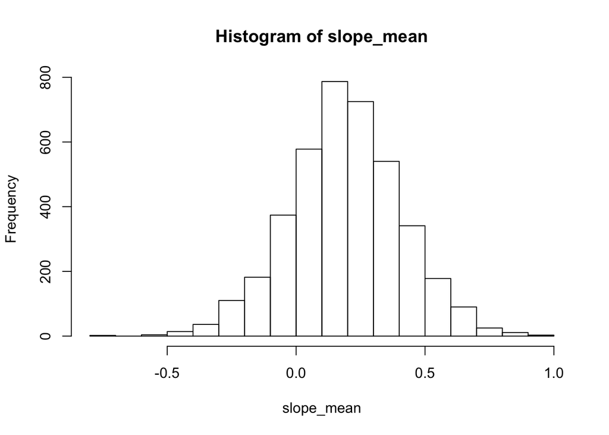

```r
hist(slope_mean)
```

Let’s also find the credible intervals (we could also look at the print statement but I wanted to show you how you can do it in R):

```r
slope_sd_quantiles <- quantile(slope_sd, c(0.025, 0.5, 0.975))

slope_sd_quantiles
```

```
##      2.5%       50%     97.5%
## 0.6189154 0.8583303 1.3081187
```

```r
slope_mean_quantiles <- quantile(slope_mean, c(0.025, 0.5, 0.975))
slope_mean_quantiles
```

```
##       2.5%        50%      97.5%
## -0.2479293  0.1895036  0.6230814
```

Let’s take a look at the slopes for the different birds.

```r
slopes <- extract(model_results)$theta_1

posterior_mean_slopes <- colMeans(slopes)
posterior_mean_slopes <- data.frame(posterior_mean_slopes, row.names=colnames(y))

posterior_mean_slopes
```

```
##                         posterior_mean_slopes
## Sage Thrasher                      1.33234135
## Blue Jay                          -0.65391514
## Lesser Nighthawk                   0.87437229
## Grace's Warbler                    1.23861474
## Blue-headed Vireo                 -0.64428312
## Western Meadowlark                 1.33624751
## Ovenbird                          -0.61971202
## Cooper's Hawk                      0.03507939
## Black-and-white Warbler           -0.57627044
## Wood Thrush                       -0.37138566
## Cactus Wren                        1.03535917
## Cedar Waxwing                     -1.08904075
## Curve-billed Thrasher              1.04138314
## Turkey Vulture                     0.28188563
## Grasshopper Sparrow                0.25170781
## Green Heron                       -0.21154854
```

One way of thinking about what we have inferred is that if we were to fit a new bird, we have learnt a prior on its slope. Let’s see what this looks like:

```r
# Pick one realisation of our hyperprior mean:
example_slope_mean <- slope_mean[1]
example_slope_sd <- slope_sd[1]

print(example_slope_mean)
```

```
## [1] 0.5212595
```

```r
print(example_slope_sd)
```

```
## [1] 0.8872145
```

```r
# Draw one possible slope
print(rnorm(1, example_slope_mean, example_slope_sd))
```

```
## [1] -1.443654
```

But we don’t just have one sample; we want a distribution, so we do it for all the slope possibilities:

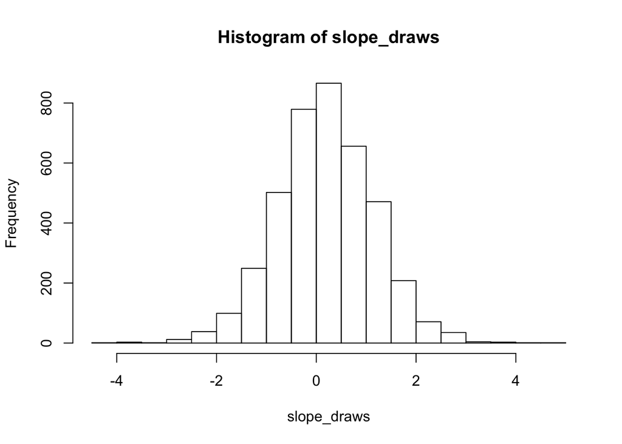

```r
slope_draws <- rnorm(length(slope_mean), mean=slope_mean, sd=slope_sd)
hist(slope_draws)
```

This is telling us that if we want to model a new bird, our prior for its slope has a credible interval (and median) of:

```r
quantile(slope_draws, c(0.025, 0.5, 0.975))
```

```
##       2.5%        50%      97.5%
## -1.7298154  0.1828105  2.0500934
```

## Exercises

1. Increase the number of birds to 32. How long does the fit take? What are the new credible intervals for slope mean and standard deviation, as well as for the draws from them?